# Benthos Taxa

The `taxonomy.benthos` table provides a standardized reference for all taxa observed during Line Point Intercept surveys and other shallow benthic protocols during Pristine Seas expeditions. It harmonizes scientific names, taxonomic hierarchy, and ecological traits to support robust analysis, reporting, and integration across survey methods.

Each row corresponds to a unique accepted **AphiaID** from the World Register of Marine Species (WoRMS), and includes the scientific name, taxonomic ranks, common names, functional group and others.

This table supports three core functions:

- *Taxonomic resolution* — reconciles field-recorded names with accepted nomenclature
- *Trait-based analysis* — enables grouping by functional group, habitat, and ecological traits (pending)
- *Cross-dataset integration* — provides a consistent key (`accepted_aphia_id`) to link observations, field codes, and traits

## Data Sources

The table integrates multiple curated sources to ensure taxonomic consistency and trait completeness:

- **Pristine Seas Field Records**  
  Derived from diver-entered observations, fieldbooks, and expedition species lists across UVS. These are reconciled with accepted WoRMS entries.
- **World Register of Marine Species (WoRMS)**  
  Used as the taxonomic backbone. Each taxon is linked to an accepted AphiaID, with full lineage (kingdom to species) and synonym resolution.
- **Literature and Expert Knowledge**  
  Supplements functional group assignments, and ecological notes from peer-reviewed sources and expert consultation.

Together, these sources provide a robust, reproducible foundation for ecological analysis.

## Structure

### Taxonomy

These fields define the accepted scientific identity and taxonomic lineage of each record (Table 1).

Table 1: Taxonomic lineage fields for benthic taxa in the Pristine Seas Database.

[output not shown]

### Functional groups

We classify benthic organisms recorded in our surveys into functional groups, reflecting their ecological roles and growth forms. This system allows for consistent summaries of benthic cover and comparisons across sites.

- `functional_group`  
  Broad ecological category assigned based on expert knowledge of morphology, life history, and functional traits. One of:
  - `hard_coral`: Living scleractinian corals forming reef framework and colonies.
  - `cca` : Crustose coralline algae (Corallinales, Sporolithales, Hapalidiaceae); calcified red algae that form rigid crusts and contribute to reef cementation
  - `cyanobacteria`: Cyanobacterial mats and films, often opportunistic and associated with nutrient enrichment
  - `soft_coral`: Octocorals including sea fans, sea whips, and fleshy soft corals; provide structural habitat but do not build reef framework.
  - `sponges`: Poriferan colonies and structures; important in bioerosion, nutrient cycling, and benthic–pelagic coupling.
  - `algae_erect`: Erect or foliose macroalgae (greens, browns, and reds) including siphonous greens (Caulerpa, Halimeda), fleshy browns (Dictyota, Sargassum), and blade-forming reds (Laurencia, Schizymenia).
  - `algae_encrusting`: Non-coralline encrusting algae such as Peyssonnelia, Ralfsiaceae, and encrusting Lobophora; form thin crusts over substrate without significant vertical relief.
  - `turf`: Low-growing mats (<1–2 cm) of filamentous and juvenile algae, often mixed with cyanobacteria, diatoms, and detritus; functionally distinct from erect macroalgae.
  - `eam`: Endolithic algal matrix: microalgae and boring forms living within carbonate substrate, often visible as green or red bands in eroded coral skeletons.
  - `sediment|rubble|barren`: Non-living substrate categories including unconsolidated sand or silt, loose rubble, and bare rock with little or no biological cover.
  - `other`: All other benthic invertebrates not captured above (e.g., non-scleractinian cnidarians, hydrozoans, ascidians, bryozoans, echinoderms, molluscs, annelids, foraminifera)

Table 2: Schema for functional traits in `taxonomy.benthos`.

| **Field** | **Type** | **Required** | **Description** |
| --- | --- | --- | --- |
| functional_group | STRING | false | Primary functional group (‘hard_coral’, ‘cca’, ‘cyanobacteria’, ‘soft_coral’, ‘algae_erect’, etc) |

### Conservation Status (IUCN)

The `taxonomy.benthos` table includes fields derived from the IUCN Red List to support biodiversity assessments and conservation planning. Each species is matched to its most recent listing (SIS ID) and assigned a standardized category (e.g., LC, NT, VU, EN, CR)

## Summary

Overall, the `taxonomy.benthos` table contains 840 entries, representing 774 unique taxa across 142 families (Figure 2). The majority of records are hard corals, with 421 taxa.

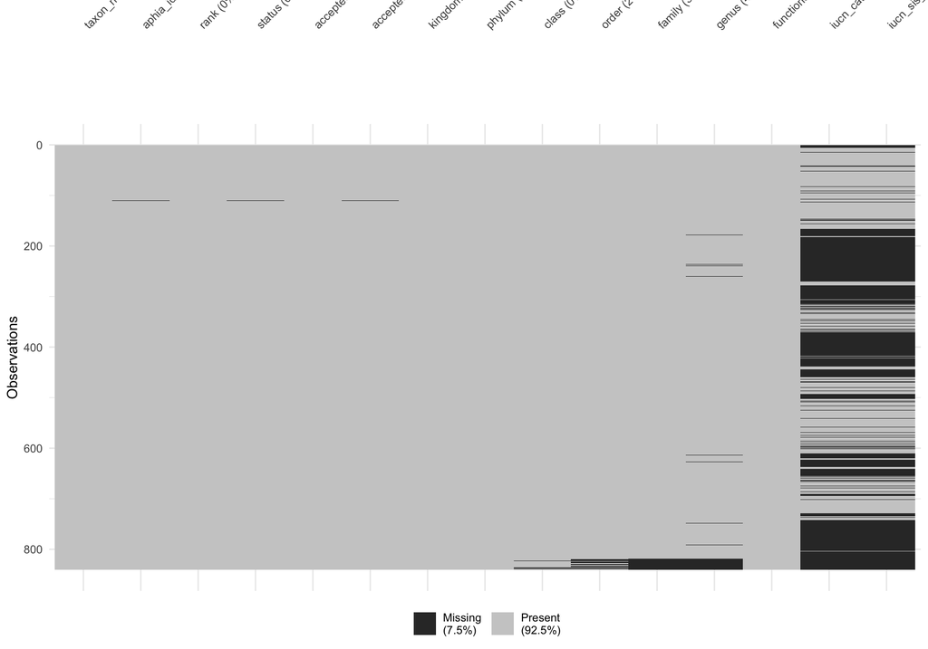

Figure 1: Missingness in the benthos taxonomy table

### By Functional Group

[interactive chart not shown]

Figure 2: Number of species by family and functional group